# Extra Credit Project: Life Expectancy in South Asia

## Dataset Overview

This dataset sourced from the World Bank gives us a detailed look at socio-economic metrics for South Asian countries from 2000 to 2023. It includes data for Bangladesh, Bhutan, India, Pakistan, Nepal, Sri Lanka, Afghanistan, and Maldives.

Some of the key indicators we can explore are:

- **Economic Metrics**: GDP, population growth, and unemployment rates.
- **Social Indicators**: Life expectancy and infant mortality.

For this project, I’ll be focusing on both the economic and social aspects of the dataset to better understand what impacts life expectancy in South Asia.

## Analysis Question

**What factors most strongly correlate with life expectancy in South Asia?**

Life expectancy is such an important measure of health and quality of life. As a clinical research scientist, by figuring out which factors are most closely related to life expectancy, I hope to get a better sense of what might drive improvements in public health.

My goal is to use this dataset to uncover meaningful relationships that can offer insights into improving health outcomes across South Asia.

```python
#Imports
import matplotlib.pyplot as plt
import pandas as pd
import numpy as np
from scipy.stats import linregress
```

## Data Cleaning

I then addressed formatting issues in critical numeric columns like GDP, GDP per Capita, and Annual Population Growth which were stored as strings with inconsistent formatting. Using the **clean_numeric_column()** function, I removed thousand separators, standardized decimal points, and converted all values to numeric data types.

I also dropped any rows with missing values in any of the key columns. Finally, I filtered the dataset to include only South Asian countries (Afghanistan, Bangladesh, Bhutan, India, Maldives, Nepal, Pakistan, and Sri Lanka) in case any other countries where accidentally included in the dataset.

```python
def clean_dataset(file_name):
    data = pd.read_csv(file_name)
    data.rename(columns={
        'Life expectancy at birth, total (years)': 'Life Expectancy',
        'Mortality rate, infant (per 1,000 live births)': 'Infant Mortality Rate (per 1,000 live births)',
        'GDP (current US$)': 'GDP (US$)',
        'GDP growth (annual %)': 'Annual GDP Growth (US$)',
        'GDP per capita (current US$)': 'GDP per Capita (US$)',
        'Unemployment, total (% of total labor force) (modeled ILO estimate)': 'Unemployment Rate (%)',
        'Population, total': 'Population',
        'Population growth (annual %)': 'Annual Population Growth'
    }, inplace=True)

    def clean_numeric_column(series):
        series = series.str.replace(r'\.', '', regex=True)
        series = series.str.replace(r',', '.', regex=True)
        return pd.to_numeric(series, errors='coerce')

    problematic_columns = ['GDP (US$)', 'Annual GDP Growth (US$)', 'GDP per Capita (US$)', 'Annual Population Growth']
    for col in problematic_columns:
        data[col] = clean_numeric_column(data[col].astype(str))

    numeric_columns = ['GDP (US$)', 'Annual GDP Growth (US$)', 'GDP per Capita (US$)',
                       'Unemployment Rate (%)', 'Population', 'Annual Population Growth',
                       'Life Expectancy', 'Infant Mortality Rate (per 1,000 live births)']
    data = data[(data[numeric_columns] > 0).all(axis=1)]

    data.dropna(subset=numeric_columns, inplace=True)

    south_asian_countries = [
        'Bangladesh', 'Bhutan', 'India', 'Pakistan',
        'Nepal', 'Sri Lanka', 'Afghanistan', 'Maldives'
    ]
    data = data[data['Country'].isin(south_asian_countries)]

    return data

file_name = 'South_Asian_dataset new.csv'
cleaned_data = clean_dataset(file_name)
```

```python
#View the dataset
cleaned_data
```

|  | Country | Year | GDP (US$) | Annual GDP Growth (US$) | GDP per Capita (US$) | Unemployment Rate (%) | Population | Annual Population Growth | Life Expectancy | Infant Mortality Rate (per 1,000 live births) |
| --- | --- | --- | --- | --- | --- | --- | --- | --- | --- | --- |
| 1 | Bhutan | 2000 | 4.607334e+09 | 3355068305 | 7846184027 | 1.652 | 587207 | 2800570184 | 62.010 | 58.4 |
| 2 | Bangladesh | 2000 | 5.336979e+10 | 5293294719 | 4131001853 | 3.270 | 129193327 | 1905524049 | 65.779 | 63.0 |
| 3 | India | 2000 | 4.680000e+16 | 3840991157 | 4420353304 | 7.856 | 1059633675 | 1822184002 | 62.669 | 66.4 |
| 4 | Maldives | 2000 | 6.243371e+09 | 3845810232 | 2209988231 | 1.970 | 282507 | 1568301447 | 70.876 | 31.8 |
| 5 | Sri Lanka | 2000 | 1.633081e+10 | 6000033158 | 8697534886 | 7.740 | 18776371 | 565924638 | 70.355 | 14.4 |
| ... | ... | ... | ... | ... | ... | ... | ... | ... | ... | ... |
| 178 | Bangladesh | 2022 | 4.600000e+16 | 7099828776 | 2687899063 | 5.247 | 171186372 | 1074836743 | 73.698 | 24.1 |
| 179 | India | 2022 | 3.350000e+17 | 6987039326 | 2366309609 | 4.822 | 1417173173 | 680372581 | 67.744 | 25.5 |
| 180 | Maldives | 2022 | 6.170639e+09 | 1390667638 | 1178081691 | 4.424 | 523787 | 445829655 | 80.839 | 4.8 |
| 182 | Nepal | 2022 | 4.118294e+10 | 5631314559 | 134815719 | 10.922 | 30547580 | 1692246601 | 70.484 | 23.0 |
| 183 | Pakistan | 2022 | 3.750000e+16 | 4767539531 | 158926398 | 5.548 | 235824862 | 1893245598 | 66.431 | 51.0 |

167 rows × 10 columns

```python
#Additional info about the dataset
print(cleaned_data.shape)
print(cleaned_data.dtypes) #Column Names and data type
print(cleaned_data.describe())
```

```
(167, 10)
Country                                           object
Year                                               int64
GDP (US$)                                        float64
Annual GDP Growth (US$)                            int64
GDP per Capita (US$)                               int64
Unemployment Rate (%)                            float64
Population                                         int64
Annual Population Growth                           int64
Life Expectancy                                  float64
Infant Mortality Rate (per 1,000 live births)    float64
dtype: object
              Year     GDP (US$)  Annual GDP Growth (US$)  \
count   167.000000  1.670000e+02             1.670000e+02
mean   2010.676647  2.375553e+16             4.742651e+09
std       6.326717  6.173012e+16             2.467488e+09
min    2000.000000  8.970312e+08             4.739567e+07
25%    2005.000000  6.186948e+09             2.943792e+09
50%    2011.000000  3.235024e+10             5.053625e+09
75%    2016.000000  1.475000e+16             6.582044e+09
max    2022.000000  3.350000e+17             9.689592e+09

       GDP per Capita (US$)  Unemployment Rate (%)    Population  \
count          1.670000e+02             167.000000  1.670000e+02
mean           3.547262e+09              47.590473  2.197128e+08
std            2.794562e+09             150.444907  4.087474e+08
min            2.050164e+07               1.652000  2.825070e+05
25%            1.250093e+09               4.214500  1.894354e+07
50%            2.689793e+09               7.461000  2.761032e+07
75%            5.021955e+09               9.339500  1.683886e+08
max            9.935034e+09             796.000000  1.417173e+09

       Annual Population Growth  Life Expectancy  \
count              1.670000e+02       167.000000
mean               1.588264e+09        68.273204
std                1.235427e+09         5.151846
min                9.653778e+06        56.454000
25%                7.921638e+08        64.672000
50%                1.243571e+09        67.403000
75%                2.150008e+09        71.251000
max                7.541019e+09        80.839000

       Infant Mortality Rate (per 1,000 live births)
count                                     167.000000
mean                                       39.834731
std                                        21.872310
min                                         4.800000
25%                                        23.750000
50%                                        38.500000
75%                                        56.500000
max                                        86.600000
```

## Heatmap of Correlations Between Numerical Factors

Now that the data has been cleaned, I moved on to determine which factors are most correlated with life expectancy. To do this, I first removed the "Country" and "Year" columns from the dataset, as they are non-numerical and irrelevant for calculating correlations. I then created a heatmap to visually display the correlation coefficients between the numerical variables. This heatmap helps identify the strength and direction of relationships between life expectancy and the other features in the dataset.

To interpret the heatmap, I focused on the row and column corresponding to "Life Expectancy." Each cell in this row or column represents the correlation between life expectancy and another feature, such as GDP, infant mortality rate, or unemployment rate. A high positive correlation (a coefficient close to +1) indicates a strong positive relationship, meaning that as the feature increases, life expectancy also tends to increase. Conversely, a high negative correlation (a coefficient close to -1) signals a strong negative relationship, where an increase in the feature corresponds to a decrease in life expectancy. If the correlation is close to zero, it means there is little to no relationship between the variables.

```python
def heatmap(data):

    numeric_data = data.select_dtypes(include=[np.number]).drop(columns=['Year'], errors='ignore')

    corr_matrix = numeric_data.corr()

    fig, ax = plt.subplots(figsize=(10, 8))
    cax = ax.matshow(corr_matrix, cmap='coolwarm')
    plt.colorbar(cax)

    ax.set_xticks(np.arange(len(corr_matrix.columns)))
    ax.set_yticks(np.arange(len(corr_matrix.columns)))
    ax.set_xticklabels(corr_matrix.columns, rotation=45, ha="left")
    ax.set_yticklabels(corr_matrix.columns)

    plt.title("Heatmap of Correlations Between Numerical Features", pad=20)
    plt.show()
```

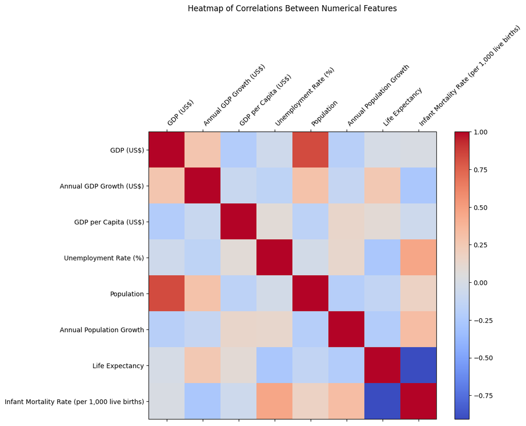

```python
#View heatmap
heatmap(cleaned_data)
```

## Linear Regression

I also like that linear regression provides a visual way to validate the fit of the data through a scatter plot and regression line. This is particularly useful because in real-world contexts, countries with high life expectancy like the United States often have very low or nonexistent IMR. This pattern reinforces the appropriateness of a linear model to capture the relationship.

```python
def linear_regression(data):

    X = data['Infant Mortality Rate (per 1,000 live births)']
    y = data['Life Expectancy']

    slope, intercept, r_value, p_value, std_err = linregress(X, y)

    print(f"Slope: {slope}")
    print(f"Intercept: {intercept}")
    print(f"R-squared: {r_value**2}")
    print(f"P-value: {p_value}")
    print(f"Standard Error: {std_err}")

    plt.figure(figsize=(10, 6))
    plt.scatter(X, y, label='Data Points', alpha=0.7)
    plt.plot(X, slope * X + intercept, color='red', label='Regression Line')
    plt.title('Infant Mortality Rate vs. Life Expectancy')
    plt.xlabel('Infant Mortality Rate (per 1,000 live births)')
    plt.ylabel('Life Expectancy')
    plt.legend()
    plt.grid(True)
    plt.show()
```

```
Slope: -0.21376484325376763
Intercept: 76.78846852252313
R-squared: 0.82363754751176
P-value: 4.5985676963298756e-64
Standard Error: 0.007700684045886526
```

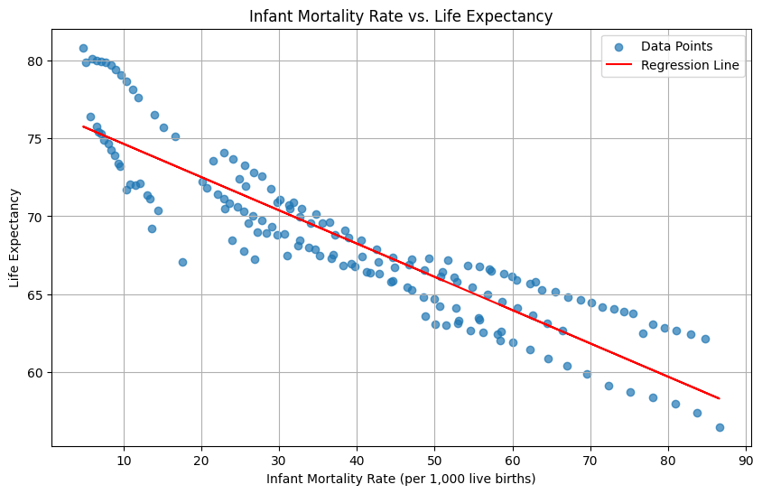

```python
#View linear regression between IMR and Life expectancy
linear_regression(cleaned_data)
```

The results from the linear regression confirm a strong and significant inverse relationship between infant mortality rate (IMR) and life expectancy (LE). With a slope of -0.2138, the model shows that for every unit increase in IMR, life expectancy decreases by approximately 0.21 years. The high R-squared value (82.36%) indicates that IMR explains the majority of the variability in life expectancy, and the extremely small p-value confirms this relationship is statistically significant. These findings align with the expectation that countries with high life expectancy typically have very low or nonexistent IMR.

## Country-Wise Comparison of LE and IMR

Building on the earlier analysis, where I identified infant mortality rate (IMR) as the factor most strongly correlated with life expectancy (LE), I wanted to explore how these metrics vary across individual South Asian countries. By comparing average life expectancy and IMR side-by-side for each country, I can better understand which countries are performing well and which ones may need improvement. These visualizations also help confirm the relationship I observed earlier: higher life expectancy tends to align with lower IMR.

I also labeled the countries with the highest and lowest averages for each metric and included the regional averages for reference. This provides a clear picture of how individual countries compare to their neighbors and highlights any outliers or exceptional performers.

```python
def country_wise_comparison(data):

    country_stats = data.groupby('Country')[['Life Expectancy', 'Infant Mortality Rate (per 1,000 live births)']].mean()

    country_stats = country_stats.sort_values('Life Expectancy', ascending=True)

    avg_life_expectancy = country_stats['Life Expectancy'].mean()
    avg_imr = country_stats['Infant Mortality Rate (per 1,000 live births)'].mean()

    min_life_expectancy_country = country_stats['Life Expectancy'].idxmin()
    max_life_expectancy_country = country_stats['Life Expectancy'].idxmax()
    min_imr_country = country_stats['Infant Mortality Rate (per 1,000 live births)'].idxmin()
    max_imr_country = country_stats['Infant Mortality Rate (per 1,000 live births)'].idxmax()

    fig, axes = plt.subplots(2, 1, figsize=(14, 16), sharex=False)

    # Life Expectancy plot
    country_stats['Life Expectancy'].plot(kind='barh', ax=axes[0], color='skyblue', edgecolor='black')
    axes[0].axvline(avg_life_expectancy, color='red', linestyle='--', linewidth=1.5, label=f'Average: {avg_life_expectancy:.2f}')
    axes[0].text(avg_life_expectancy + 1, len(country_stats) - 1, f"Avg: {avg_life_expectancy:.2f}", color="red", fontsize=10)
    axes[0].set_title('Average Life Expectancy by Country', fontsize=14)
    axes[0].set_xlabel('Life Expectancy (Years)', fontsize=12)
    axes[0].set_ylabel('Country', fontsize=12)
    axes[0].tick_params(axis='x', labelsize=10)
    axes[0].tick_params(axis='y', labelsize=10)
    axes[0].grid(axis='x', linestyle='--', alpha=0.7)
    axes[0].legend(loc='lower right', fontsize=10)

    min_life_expectancy = country_stats['Life Expectancy'].min()
    max_life_expectancy = country_stats['Life Expectancy'].max()
    axes[0].annotate(f"Min: {min_life_expectancy:.2f} ({min_life_expectancy_country})",
                     xy=(min_life_expectancy, country_stats.index.get_loc(min_life_expectancy_country)),
                     xytext=(min_life_expectancy - 5, country_stats.index.get_loc(min_life_expectancy_country) + 0.5),
                     arrowprops=dict(facecolor='black', arrowstyle='->'),
                     fontsize=10, color='black')
    axes[0].annotate(f"Max: {max_life_expectancy:.2f} ({max_life_expectancy_country})",
                     xy=(max_life_expectancy, country_stats.index.get_loc(max_life_expectancy_country)),
                     xytext=(max_life_expectancy - 10, country_stats.index.get_loc(max_life_expectancy_country) - 0.5),
                     arrowprops=dict(facecolor='black', arrowstyle='->'),
                     fontsize=10, color='black')

    # Infant Mortality Rate plot
    country_stats['Infant Mortality Rate (per 1,000 live births)'].plot(kind='barh', ax=axes[1], color='orange', edgecolor='black')
    axes[1].axvline(avg_imr, color='blue', linestyle='--', linewidth=1.5, label=f'Average: {avg_imr:.2f}')
    axes[1].text(avg_imr + 1, len(country_stats) - 1, f"Avg: {avg_imr:.2f}", color="blue", fontsize=10)
    axes[1].set_title('Average Infant Mortality Rate by Country', fontsize=14)
    axes[1].set_xlabel('Infant Mortality Rate (per 1,000 live births)', fontsize=12)
    axes[1].set_ylabel('Country', fontsize=12)
    axes[1].tick_params(axis='x', labelsize=10)
    axes[1].tick_params(axis='y', labelsize=10)
    axes[1].grid(axis='x', linestyle='--', alpha=0.7)
    axes[1].legend(loc='upper right', fontsize=10)

    min_imr = country_stats['Infant Mortality Rate (per 1,000 live births)'].min()
    max_imr = country_stats['Infant Mortality Rate (per 1,000 live births)'].max()
    axes[1].annotate(f"Min: {min_imr:.2f} ({min_imr_country})",
                     xy=(min_imr, country_stats.index.get_loc(min_imr_country)),
                     xytext=(min_imr + 10, country_stats.index.get_loc(min_imr_country) + 0.5),
                     arrowprops=dict(facecolor='black', arrowstyle='->'),
                     fontsize=10, color='black')
    axes[1].annotate(f"Max: {max_imr:.2f} ({max_imr_country})",
                     xy=(max_imr, country_stats.index.get_loc(max_imr_country)),
                     xytext=(max_imr - 20, country_stats.index.get_loc(max_imr_country) - 0.5),
                     arrowprops=dict(facecolor='black', arrowstyle='->'),
                     fontsize=10, color='black')

    plt.tight_layout()
    plt.show()
```

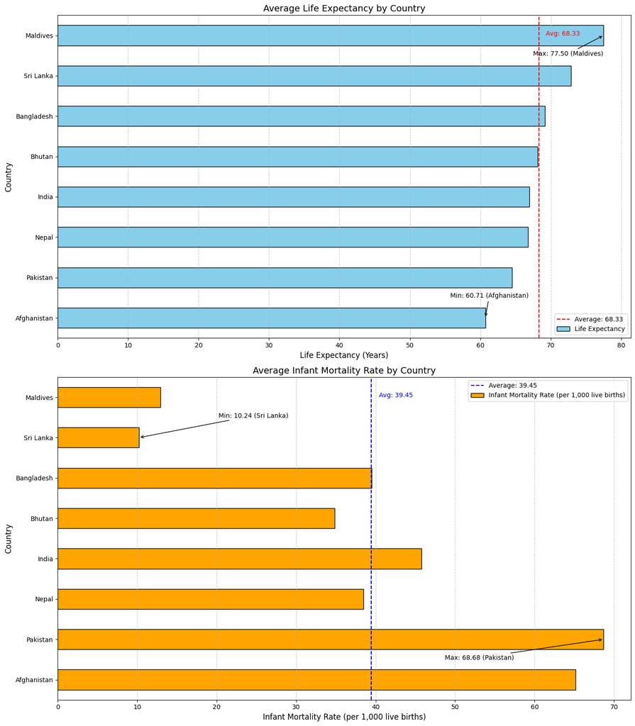

```python
# View LE and IMR Country Plots
country_wise_comparison(cleaned_data)
```

The graphs provide a clear comparison of life expectancy and infant mortality rates (IMR) across South Asian countries. From the Average Life Expectancy by Country chart, we can see that the Maldives has the highest average life expectancy at 77.50 years, while Afghanistan has the lowest at 60.71 years. The regional average life expectancy is 68.33 years, which serves as a useful benchmark to evaluate the relative performance of each country. Countries like Sri Lanka and Bangladesh are slightly above the regional average, whereas Afghanistan, Pakistan, India, and Nepal fall below it.

In the Average Infant Mortality Rate (IMR) by Country chart, Pakistan has the highest IMR at 68.68 deaths per 1,000 live births, while Sri Lanka has the lowest IMR at just 10.24 deaths per 1,000 live births. The regional average IMR is 39.45 deaths per 1,000 live births. Countries like Sri Lanka and the Maldives have notably low IMR values, indicating better healthcare outcomes, whereas Afghanistan and Pakistan exceed the average in constrast.

These visualizations again emphasize the strong inverse relationship between life expectancy and IMR observed earlier. Countries with higher life expectancy, like the Maldives and Sri Lanka, tend to have much lower IMR, while countries with lower life expectancy, such as Afghanistan and Pakistan, exhibit higher IMR values. This reinforces the importance of reducing infant mortality to improve overall life expectancy in the region.

## Trends Over Time

Finally, I wanted to examine how life expectancy and infant mortality rate (IMR) have changed over the years (2000–2022) for each South Asian country to better understand these dynamics over time. While the earlier analyses provided insights into correlations and country-specific differences, this final step focuses on identifying trends. By doing so, I can observe which countries have made consistent progress in improving life expectancy and reducing IMR, as well as those that may have experienced stagnation or slower growth.

By plotting these trends, I wanted to highlight which countries are showing significant improvements and which are not making as much progress. These trends may also reveal the potential impact of policy changes, economic growth, or health initiatives on these critical indicators. Comparing all countries on the same graphs allows me to see who is leading or lagging in improving both life expectancy and IMR.

```python
def trends(data):

    countries = data['Country'].unique()

    fig, axs = plt.subplots(2, 1, figsize=(12, 14), sharex=True)

    for country in countries:
        country_data = data[data['Country'] == country]

        axs[0].plot(country_data['Year'], country_data['Life Expectancy'], label=country, marker='o')

        axs[1].plot(country_data['Year'], country_data['Infant Mortality Rate (per 1,000 live births)'], label=country, marker='o')

    axs[0].set_title('Life Expectancy Trends (2000–2022)', fontsize=14)
    axs[0].set_ylabel('Life Expectancy (Years)')
    axs[0].legend(title='Country', bbox_to_anchor=(1.05, 1), loc='upper left')
    axs[0].grid(True)

    axs[1].set_title('Infant Mortality Rate Trends (2000–2022)', fontsize=14)
    axs[1].set_ylabel('Infant Mortality Rate (per 1,000 live births)')
    axs[1].set_xlabel('Year')
    axs[1].legend(title='Country', bbox_to_anchor=(1.05, 1), loc='upper left')
    axs[1].grid(True)

    plt.tight_layout()
    plt.show()
```

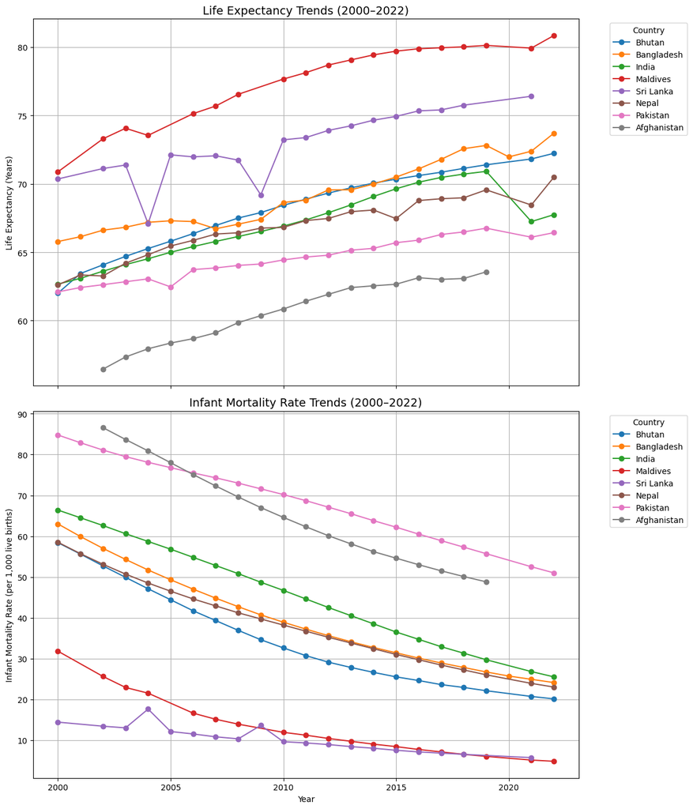

```python
#View trends plots
trends(cleaned_data)
```

The graphs above illustrate the trends in life expectancy and infant mortality rate (IMR) from 2000 to 2022 for South Asian countries.

These trends not only emphasize regional differences in health outcomes but also drive home the strong correlation between IMR and life expectancy identified in earlier analyses. As IMR declines, life expectancy increases almost universally, signifing the critical role of reducing infant mortality in improving overall health outcomes. This suggests that socioeconomic factors, healthcare policies, and interventions vary significantly across the region, impacting progress in life expectancy and infant mortality rates.